# DEG for recurrence versus non-recurrence in TCGA-HNSC

For reproducing the plots, load the relevant rds files: DEG_res.rds and PlotDEG_box.rds.

# Get relevent case id

```r
library(dplyr)
# all cases in TCGA-HNSC
follow_ups=read.delim("metadata/clinical.cohort.2025-07-19/follow_up.tsv")
length(table(follow_ups$cases.submitter_id))
#follow_ups$follow_ups.progression_or_recurrence
#follow_ups$follow_ups.timepoint_category
#follow_ups$follow_ups.disease_response


# 1. Identify recurrence
#    Any row with this id has follow_ups.progression_or_recurrence == "Yes"
type1_ids <- follow_ups %>%
  group_by(cases.submitter_id) %>%
  summarise(
    is_type1 = any(follow_ups.progression_or_recurrence == "Yes"),
    .groups = 'drop' # Drop grouping after summarise
  ) %>%
  filter(is_type1) %>%
  select(cases.submitter_id) %>%
  distinct()

# 2. Identify submitter_ids that *do not* have progression/recurrence
no_progression_ids <- follow_ups %>%
  group_by(cases.submitter_id) %>%
  summarise(
    has_no_progression = all(follow_ups.progression_or_recurrence != "Yes"),
    .groups = 'drop'
  ) %>%
  filter(has_no_progression) %>%
  select(cases.submitter_id)

# 3. Keep only those diagnosed as Tumor Free in the last contact for non-recurrence

type2_ids <- follow_ups %>%
  inner_join(no_progression_ids, by = "cases.submitter_id") %>% # Only consider those with no progression
  group_by(cases.submitter_id) %>%
  summarise(
    is_type2 = any(follow_ups.timepoint_category == "Last Contact" &
                     follow_ups.disease_response == "TF-Tumor Free"),
    .groups = 'drop'
  ) %>%
  filter(is_type2) %>%
  select(cases.submitter_id) %>%
  distinct()

type1_ids$type<-"recurrence"
type2_ids$type<-"non-recurrence"
all_id <-rbind(type1_ids,type2_ids)
#write.csv(all_id,"case_id.csv")

# import case ids to GDC cohort builder. Filter for no prior treatment,
# no synchronous malignancy and get 412 cases. Download RNAseq count tables, filtering for
# gene expression qualification,tumor, primary. End up with  411 expression files.
```

# load Demographic Factors, Exposure Factors and expression data

Age, sex, smoker,alcohol,race

## load expression data

```r
files <- dir(pattern = "gene_counts.tsv$",recursive = T,full.names = T)

# Initialize an empty data frame to store the gene expression data
gene_expression <- data.frame()

# Loop over each file
for (file in files) {
  # Read the file into a data frame, skipping the first 5 rows (header and N_* rows)
  df <- read.table(file, header = TRUE, skip = 6, sep = "\t", row.names = 1)
  colnames(df) <- c(    'gene_name' ,'gene_type'    ,'unstranded'   ,'stranded_first'   ,'stranded_second'  ,'tpm_unstranded',  'fpkm_unstranded',  'fpkm_uq_unstranded')
  # Extract the 'unstranded' column
  df <- df[, "unstranded", drop = FALSE]

  # Rename the column to the file name (without the path )
  colnames(df) <- gsub(".*/", "", basename(file))

  # If gene_expression is empty, set it to df; otherwise, merge it with df
  if (ncol(gene_expression) == 0) {
    gene_expression <- df
  } else {
    gene_expression <- merge(gene_expression, df, by = "row.names", all = TRUE)
    rownames(gene_expression) <- gene_expression$Row.names
    gene_expression$Row.names <- NULL
  }
}

# Fill missing values with 0 (since gene expression can't be missing)
gene_expression[is.na(gene_expression)] <- 0

head(gene_expression)
```

map expression file ids to cases.submitter_id to get the final gene_expresion matrix

```r
# Read the metadata file
metadata <- read.table("metadata/gdc_sample_sheet.2025-07-22.tsv", header = TRUE, sep = "\t", stringsAsFactors = FALSE)

# Create a named vector mapping file names to Case IDs
file_to_case_id <- setNames(metadata$Case.ID, metadata$File.Name)

# Replace the column names in gene_expression with Case IDs
colnames(gene_expression) <- file_to_case_id[colnames(gene_expression)]
head(gene_expression)
#write.csv(gene_expression, "gene_expression.csv", quote = FALSE, row.names = TRUE)
```

## load metadata and merge them to one table

```r
# Make sure the column names in 'metadata' are correctly specified
colnames_to_keep <- c("demographic.age_at_index", "demographic.gender", "demographic.race")

# Extract the sample IDs from the column names of 'gene_expression'
sample_ids <- colnames(gene_expression)

# Read the clinical data file
metadata <- read.delim("metadata/clinical.cohort.2025-07-19/clinical.tsv", header = TRUE, sep = "\t", stringsAsFactors = FALSE)

# Find the matching rows in 'metadata'
matching_rows <- metadata[metadata$cases.submitter_id %in% sample_ids, ]

# Keep only the required columns
demographic_data <- matching_rows[, c("cases.submitter_id", colnames_to_keep)]

# Remove duplicates
demographic_data <- demographic_data %>% distinct()
print(demographic_data)
demographic_data$demographic.age_at_index <- as.numeric(demographic_data$demographic.age_at_index)
#hist(demographic_data$demographic.age_at_index)
demographic_data$age_group <- cut(demographic_data$demographic.age_at_index,
                                  breaks = c(0, 40, 60, 80, Inf),
                                  labels = c("0-40", "40-59", "60-79", "80+"),
                                  right = FALSE)
```

```r
# Make sure the column names in 'metadata' are correctly specified
colnames_to_keep <- c("exposures.tobacco_smoking_status", "exposures.alcohol_history")

# Extract the sample IDs from the column names of 'gene_expression'
sample_ids <- colnames(gene_expression)

# Read the clinical data file
metadata <- read.delim("metadata/clinical.cohort.2025-07-19/exposure.tsv", header = TRUE, sep = "\t", stringsAsFactors = FALSE)

# Find the matching rows in 'metadata'
matching_rows <- metadata[metadata$cases.submitter_id %in% sample_ids, ]

# Keep only the required columns
exposures_data <- matching_rows[, c("cases.submitter_id", colnames_to_keep)]

# Remove duplicates
exposures_data<-exposures_data %>%
  group_by(cases.submitter_id) %>%
  summarise(
    exposures.tobacco_smoking_status = ifelse(all(exposures.tobacco_smoking_status == "'--"), "Unknown", names(which.max(table(exposures.tobacco_smoking_status[exposures.tobacco_smoking_status != "'--"])))),
    exposures.alcohol_history = ifelse(all(exposures.alcohol_history == "'--"), "Unknown", names(which.max(table(exposures.alcohol_history[exposures.alcohol_history != "'--"]))))
  )
head(exposures_data)
```

```r
data.table <- all_id %>%
  left_join(demographic_data, by = "cases.submitter_id") %>%
  left_join(exposures_data, by = "cases.submitter_id")
head(data.table)
write_csv(data.table,"meta_table.csv",col_names = T,quote = "none")
```

# DESeq analysis

## test run to see if there are any outliers

```r
library(DESeq2)
library(BiocParallel)
register(MulticoreParam(10))

# 1. Make DESeq2 dataset

gene_expression <-read.csv("gene_expression.csv")
row.names(gene_expression)<-gene_expression[,1]
gene_expression<-gene_expression[,-1]
rownames(data.table) <- data.table$cases.submitter_id
all(colnames(gene_expression)%in% rownames(data.table) )
data.table <- data.table[colnames(gene_expression),]
dds <- DESeqDataSetFromMatrix(
  countData = gene_expression,
  colData = data.table,
  design = ~ 1 # No group/differential term for PCA, just exploring
)

# 2. Variance-stabilizing transformation (VST)
vsd <- vst(dds, blind = TRUE)

# 3. PCA and plot, try all factors here
plotPCA(vsd, intgroup = c("exposures.alcohol_history"))
```

## remove unknown values and run DESeq2

```r
# no outliers identified
test_coldata <-data.table[,-3]
head(test_coldata)
colnames(test_coldata)
test_coldata <-test_coldata %>%
  filter(!if_any(everything(), ~ . %in% c("not reported", "Unknown")))
test_coldata$merge_condition<-apply(test_coldata[, 2:ncol(test_coldata)], 1, paste, collapse = " ")
table(test_coldata$merge_condition)
test_coldata <- test_coldata %>%
  mutate(across(2:ncol(test_coldata), factor))

rownames(test_coldata)<-test_coldata$cases.submitter_id
dds <- DESeqDataSetFromMatrix(
  countData = gene_expression[,rownames(test_coldata)], # Counts must be integers
  colData = test_coldata,
  design = ~  age_group+demographic.gender+demographic.race+exposures.tobacco_smoking_status+exposures.alcohol_history+type)

dds$type<-factor(dds$type, levels = c("non-recurrence","recurrence"))
dds$age_group<-factor(dds$age_group, levels = c("0-40","40-59","60-79","80+"))
dds$exposures.tobacco_smoking_status<-factor(dds$exposures.tobacco_smoking_status, levels = c("Lifelong Non-Smoker","Current Reformed Smoker for > 15 yrs","Current Reformed Smoker for < or = 15 yrs","Current Smoker"))

dds <- DESeq(dds)
res <- results(dds) # look at the last factor (i.e. type) by default

#saveRDS(res, file = "DEG_res.rds")
```

end up with 176 cases with no unknown values

```r
library(DESeq2)
res <- readRDS("DEG_res.rds") # look at the last factor (i.e. type) by default
head(rownames(res))
```

map Ensembl ids to hgnc

```r
library(biomaRt)

# Remove version numbers from Ensembl IDs
ids <- gsub("\\..*", "", rownames(res))  # Removes e.g., ".17" from "ENSG00000000460.17"

# Connect to Ensembl
mart <- useEnsembl(biomart = "genes", dataset = "hsapiens_gene_ensembl")

# Get mapping
gene_map <- getBM(
  attributes = c("ensembl_gene_id", "hgnc_symbol"),
  filters = "ensembl_gene_id",
  values = ids,
  mart = mart
)
# Merge IDs back into result table
res$ensembl_gene_id <- ids
res_annot <- merge(as.data.frame(res), gene_map, by = "ensembl_gene_id", all.x = TRUE)


# Prepare labels: use gene symbol where available, else Ensembl ID
labels <- ifelse(is.na(res_annot$hgnc_symbol) | res_annot$hgnc_symbol=="",
                 res_annot$ensembl_gene_id,
                 res_annot$hgnc_symbol)

head(res_annot)
#write_csv(res_annot,"DEG_result.csv",col_names = T,quote = "none")
```

Volcano plot

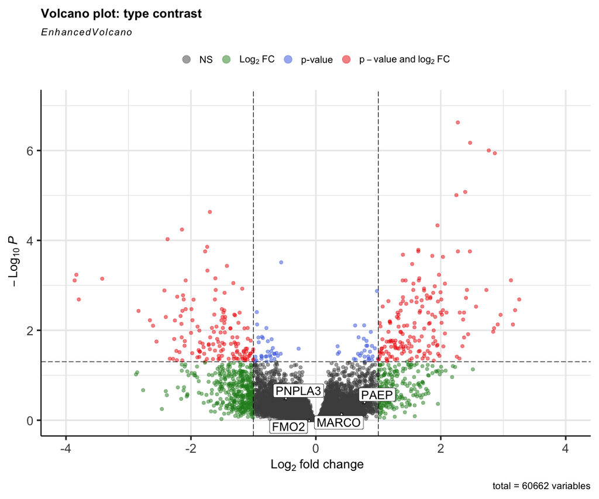

We are specifically looking at the four genes of interest. So no need to adjust pvalue here. For instance, the H0 hypothesis for PAEP is: There is no significant change in expression between the recurrence group and non-recurrence group. We only test this hypothesis once.

```r
genes_of_interest <- c("FMO2", "PAEP", "MARCO", "PNPLA3")

# Subset the annotated results for these genes
gene_stats <- res_annot[res_annot$hgnc_symbol %in% genes_of_interest,
                        c("hgnc_symbol", "log2FoldChange", "pvalue")]

# Print the results
print(gene_stats)
```

```r
library(tidyverse)
# 1. Get vst-transformed counts and sample metadata
vst_mat <- assay(vst(dds))
metadata <- as.data.frame(colData(dds))
metadata$sample <- rownames(metadata)

# 2. Remove version from Ensembl IDs
rownames(vst_mat) <- gsub("\\..*", "", rownames(vst_mat))

# 3. Map Ensembl to gene symbol
# Let's assume gene_map is a data.frame with columns: 'ensembl_gene_id', 'hgnc_symbol'
genes_of_interest <- c("FMO2", "PAEP", "MARCO", "PNPLA3")
ens_ids <- gene_map$ensembl_gene_id[gene_map$hgnc_symbol %in% genes_of_interest]

# 4. Extract expression for those genes and label with gene symbol
expr <- vst_mat[rownames(vst_mat) %in% ens_ids, ]
gene_symbols <- gene_map$hgnc_symbol[match(rownames(expr), gene_map$ensembl_gene_id)]
rownames(expr) <- gene_symbols

# 5. Convert to tidy format for ggplot2
library(tidyverse)
expr_df <- as.data.frame(expr) %>%
  mutate(gene = rownames(expr)) %>%
  pivot_longer(
    -gene,
    names_to = "sample",
    values_to = "expression"
  )
# 6. Add 'type' information
plot_df <- expr_df %>%
  left_join(metadata, by = "sample")
#saveRDS(plot_df,"plotDEG_box.rds")
```

```r
plot_df<-readRDS("plotDEG_box.rds")

# 7. Make boxplot: genes on x, expression on y, "type" as box color/fill
#pdf("DEG_target_genes.pdf", width = 6, height = 5, pointsize = 12 )
ggplot(plot_df, aes(x = gene, y = expression, fill = type)) +
  geom_boxplot(
    outlier.shape = NA,
    alpha = 0.7,
    position = position_dodge(width = 0.8)
  ) +
  geom_jitter(
    alpha = 0.4,
    position = position_jitterdodge(jitter.width = 0.15, dodge.width = 0.8)
  ) +
  labs(
    x = "Gene",
    y = "VST Normalized Expression",
    fill = "Type",
    title = "Expression of Selected Genes by Type"
  ) +
  theme_bw() +
  theme(legend.position = "right")
#dev.off()
```

[output not shown]

check if the top DE genes here is interesting.

```r
signif_res <- res_annot %>%
  filter(!is.na(padj))                       # Keep only genes with available padj

# Top 10 up-regulated
top_up <- signif_res %>%
  arrange(desc(log2FoldChange)) %>%
  slice_head(n = 10)

# Top 10 down-regulated
top_down <- signif_res %>%
  arrange(log2FoldChange) %>%
  slice_head(n = 10)

# Show results
top_up
```

```r
top_down
```